# Cointegration Numerics

11 March, 2016

Spurious correlation!

Number of Nicholas Cage Movies  
*versus*  
Drownings by Falling into a Swimming Pool

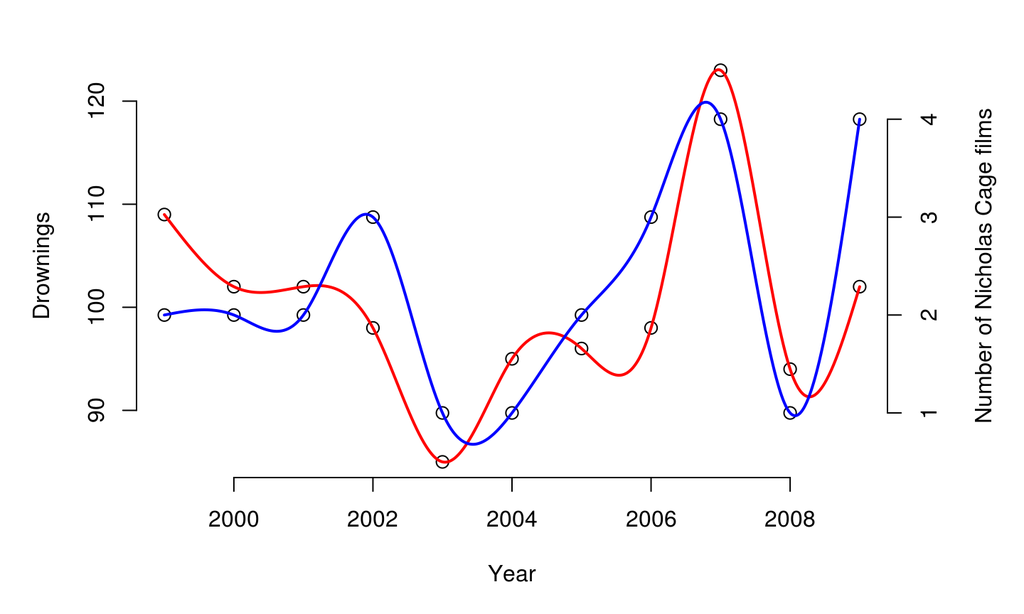

<sub>From: tylervigen.com.</sub>

Standard statistical methods applied to general time series might not work.

Cointegration extends regression methods to cover more cases.

I'll talk about implementation of solution methods.

## Background

## Generating model

I(0) time series are formally expressed

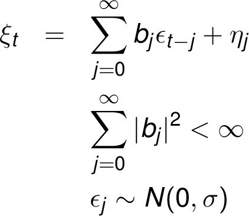

## Vector of n most recent values

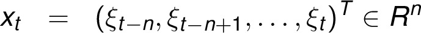

## Integration order

A series x<sub>t</sub> is called I(1) if

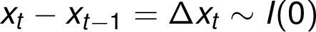

## Cointegration

The I(1) vector x<sub>t</sub> is *cointegrated* if there exists a vector β such that

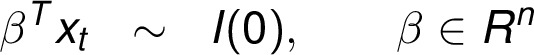

## An autoregressive model

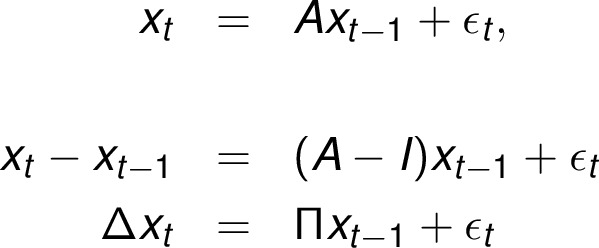

Simplified. The VECM extends this.

## Cointegration from this view

The I(1) series x<sub>t</sub> has cointegration rank 1 if

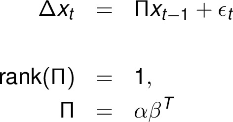

## Rank r cointegration of k series

Require each series to be I(1).

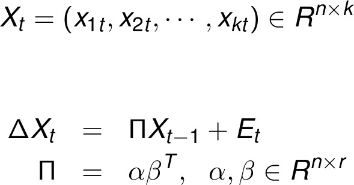

<sup>α, β full column rank</sup>

## Intuition

... and Haiku

## A very drunk man. Out walking his faithful dog. Cointegration.

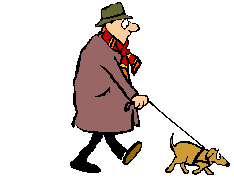

## Testing for cointegration rank r

Find α, β of rank r (not unique!).

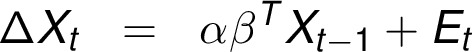

## MLE solution

Johansson developed a maximum likelihood estimate of α and β.

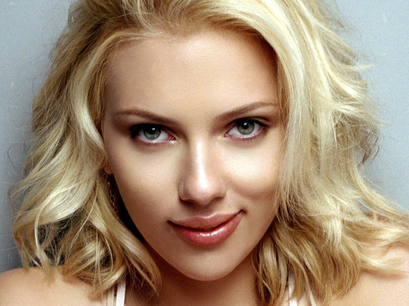

**Not that Johansson!**  
Actually, it was Søren Johans*en*, the Danish economist.

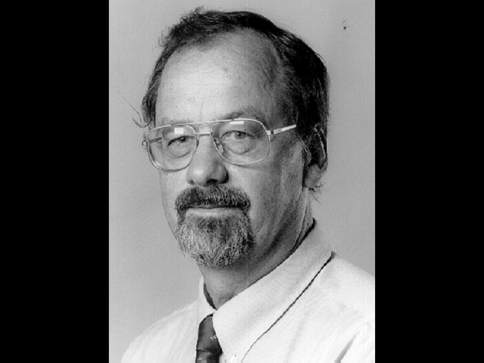

## Let

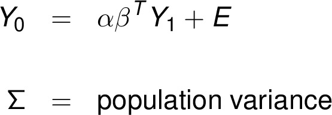

Simplified. The Y<sub>j</sub> matrices are derived from X<sub>t</sub>.

## Likelihood function

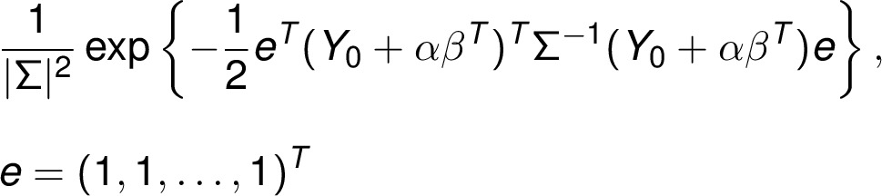

## Sample covariance estimate

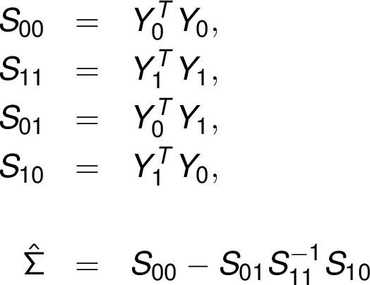

## MLE requires solving

## A generalized eigenvalue problem!

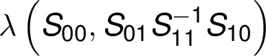

We need that

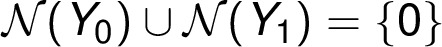

## Notes

Johansen shows that

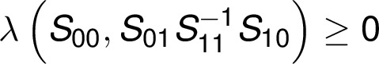

We desire the eigenvalues and a basis for the span of the columns of β.

## One solution: The Generalized SVD

Write

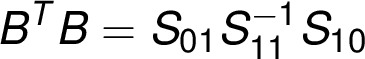

Then there exist U, V w/orthonormal columns and nonsingular Z s.t.:

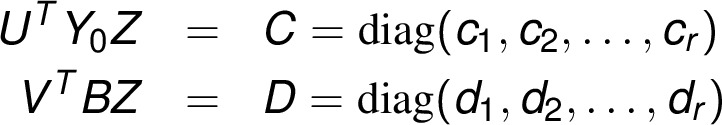

## Solutions

Generalized singular values

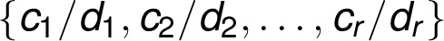

Generalized eigenvalues of

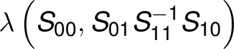

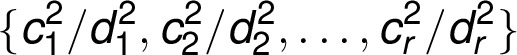

## Alternative approach

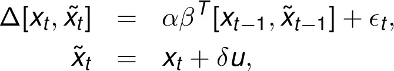

shows a complete loss of accuracy for δ < 10<sup>-6</sup> when solved directly but works fine with the SVD approaches.

## References

Doornik, Jurgen A., and R. J. O'Brien. "Numerically stable cointegration analysis." Computational statistics & data analysis 41.1 (2002): 185-193.  
Johansen, Søren. "Statistical analysis of cointegration vectors." Journal of economic dynamics and control 12.2 (1988): 231-254.

These slides are available at  
http://illposed.net/cointegration.html